# Game: Snake Devlog

This article goes through the full process of making and testing the `Snake` ROM. Snake is a good game to demonstrate the basic input and gamelogic functionality of the package, and it doesn’t require fancy graphics; graphical capabilities are explored in `vignette("rcade.super_rrio")`.

This article includes all of the code in the `Snake` ROM, in collapsible chunks like this:

**`Example Code [click to expand]`**

```r
library(rcade)
```

## 1. Engine Structure

A ROM is an object (list) made with `rom.init()` that the package can use to play a game. A ROM contains all the *static* data of the game— game logic, sprites, and so on. This is what we’re building in this article.

Once you have a ROM, you play it by making a RAM object—which stores all the *dynamic* data for the game—and running it with `ram.run()`. This runs the game code from the ROM, which references and writes to variables in the RAM. You’ll see that most of the game code in this article works with the RAM.

`vignette("rcade.guide")` provides an overview of this process for playing games, and `vignette("rcade.engine")` describes the ROM/RAM in a little more detail.

## 2. Setup

Before we start, we have to make some decisions about how the game will work.

- The snake will be controlled with WASD, since R can’t capture arrow key presses.
- The speed of the snake will be determined by the game’s framerate, since there’s no point to drawing it any faster than that.
- We’ll use an arbitrary game area of 16x8 for now, and change it later.

### 2.1 ROM Initialization

To start, we create the ROM object.

```r
Snake = rom.init(16,8,framerate=2,sprites=list(pixel=matrix(1)))
```

There’s more we can add with this function (`rom.init()`), but this is all we need for now; we’ll add additional properties to the object throughout the article.

So far, we’ve:

- set game area to 16x8
- set framerate to 2 frames per second
- created a single sprite called “pixel” which is a 1x1 pixel

And the game automatically uses the default WASD controls:[^1]

```r
#Snake$keybinds = c(w = 'up', a = 'left', s = 'down', d = 'right')
```

## 3. Moving the Snake

The first step is to make the snake head object, which is what the player controls.

### 3.1 Initialization

We’ll initialize this object in `Snake$startup`, which runs once when the RAM is initialized. This is where we want to create objects that will be used later— it’s like the top of a code file.

**`Snake$startup`**

```r
Snake$startup = function(RAM){
  RAM$objects$head = list(
        x = floor(RAM$ROM$screen.width / 2),
        y = floor(RAM$ROM$screen.height / 2),

        spritename = 'pixel',

        direction = 'neutral'
    )
  return(RAM)
}
```

The snake (`head` object) starts at the center of the screen and has the direction ‘neutral’ to indicate it hasn’t started moving yet.

### 3.2 Control

We’ll control the snakehead by changing its `$direction`. We can do this by checking `RAM$actions` for player-input directions, and setting `head$direction` if a new valid direction has been input.

We want this code to run every tick in `Snake$custom()`, but instead of cluttering that function, we can make a new function and call it in `Snake$custom()`. We can’t just define this new function in the basic R environment— the RAM would have no way to access it in its environment. So instead we make it a part of the ROM. Then, the RAM can run it with `RAM$ROM$set_direction()`, since the RAM has access to a copy of ROM.

**`Snake$set_direction`**

```r
Snake$set_direction = function(RAM){
  #name of the actions pressed on this tick, or NULL
  actions = names(RAM$actions)[which(RAM$actions == TRUE)]

  #print the direction so we know it's working
  RAM$echo = paste(actions,collapse = ' ')

  #set head direction
  if (length(actions)) RAM$objects$head$direction = actions[[1]]

  return(RAM)
}
```

### 3.3 Movement

Now we move the head based on its direction.

**`Snake$move_head`**

```r
Snake$move_head = function(RAM){
  head = RAM$objects$head #for typing convenience

  print(head)
  #convert direction name to x and y
    direction = list(
      'neutral' = c(0,0),
        'left'= c(-1,0),
        'right' = c(1,0),
        'up' = c(0,-1),
        'down' = c(0,1)
    )[[head$direction]]

    head$x = head$x + direction[1]
    head$y = head$y + direction[2]

    RAM$objects$head = head #push changes

    return(RAM)
}
```

### 3.4 Testing

Putting this all together, we already have a working prototype where we can control the head!

**Code SO FAR:**

```r
Snake = rom.init(16,8,framerate=2,sprites=list(pixel=matrix(1)))

#define helper functions (see preceding sections)
Snake$set_direction = function...
Snake$move_head = function...

Snake$startup = function(RAM){
  RAM$objects$head = list(
        x = floor(RAM$ROM$screen.width / 2),
        y = floor(RAM$ROM$screen.height / 2),
        spritename = 'pixel',
        direction = 'neutral'
    )
  return(RAM)
}

Snake$custom = function(RAM){
  RAM = RAM$ROM$set_direction(RAM)

  RAM = RAM$ROM$move_head(RAM)

  return(RAM)
}

RAM = ram.init(Snake) #initialize RAM
RAM = ram.run(RAM) #run game with RAM
```

[figure not shown]

## 4. Border

Next, let’s make a nice border for the game so we know where the play area ends. We can do this by generating a sprite in `Snake$startup`: We want to make the sprite dynamically like this so that the game can be played at different resolutions— if we hard-coded a sprite, it wouldn’t always fit!

**`Snake$make_border`**

```r
Snake$make_border = function(RAM){
  #make border sprite
  box = matrix(1,RAM$ROM$screen.height,RAM$ROM$screen.width)
  box[2:(nrow(box) - 1), 2:(ncol(box) - 1)] = 2

  #push this sprite to ROM$sprites
  RAM$ROM$sprites$border = box

  #make object to display sprite
  RAM$objects$border = list(spritename='border')

  return(RAM)
}
```

```
#> [][][][][][][][][][][][][][][][]
#> []                            []
#> []                            []
#> []            []              []
#> []                            []
#> []                            []
#> []                            []
#> [][][][][][][][][][][][][][][][]
```

## 5. Segments

Time to add the segments of the snake. There’s a simple trick to avoid having to keep track of the whole snake at once:

1. Every tick, the snake head moves to a new tile.
2. Spawn a segment on the empty tile the head just left.
3. Delete the oldest segment to have spawned, unless an apple was eaten this tick.

This produces exactly the behavior we want, since the “tail” of the snake always corresponds to the oldest segment.

### 5.1 Spawn Segment

New segments are spawned each frame in `Snake$custom` before moving the head:  
We use `ram.new_object()` to add nameless objects to `RAM$objects`.

**`Snake$spawn_segment`**

```r
Snake$spawn_segment = function(RAM){
  #spawn new tail segment
  RAM = ram.new_object(RAM, list(
    x = RAM$objects$head$x,
    y = RAM$objects$head$y,

    #used to find which objects are tail objects
    is_segment = TRUE,

    #tick on which this segment spawned
    time_created = RAM$ticks,

    spritename = 'pixel'
  ))

  return(RAM)
}
```

### 5.2 Remove Tail

Then we can loop through the objects, find the oldest segment, and remove it.

**`Snake$remove_tail`**

```r
Snake$remove_tail = function(RAM){
  oldest_time = Inf
  oldest_index = NULL
  for (i in 1:length(RAM$objects)){
    obj = RAM$objects[[i]]

    if (!is.null(obj$is_segment)){ #obj has $is_segment property
        if (obj$time_created < oldest_time){ #object is oldest so far
            oldest_time = obj$time_created
            oldest_index = i
        }
    }
  }
  #remove oldest segment
  RAM$objects = RAM$objects[-oldest_index]

  return(RAM)
}
```

WARNING: Because of how R handles nested objects, `RAM$objects` always has to be iterated by `for (i in 1:length(RAM$objects))`. Attempting `for (obj in RAM$objects)` will NOT work.

### 5.3 Testing

To test the segments, we’ll have to make code for the snake to grow. The snake will grow any time we don’t delete the tail segment, so let’s prevent that code from running every, say, 5 ticks. Let’s also speed up the game a little so it’s easier to test.

**Code so far:**

```r
Snake = rom.init(16,8,framerate=5,sprites=list(pixel=matrix(1)))

#helper functions from before
Snake$set_direction = function...
Snake$move_head = function...
Snake$make_border = function...
Snake$spawn_segment = function...
Snake$remove_tail = function...

Snake$startup = function(RAM){
    #make border
    RAM = RAM$ROM$make_border(RAM)

    #make head
    RAM$objects$head = list(
        x = floor(RAM$ROM$screen.width / 2),
        y = floor(RAM$ROM$screen.height / 2),
        spritename = 'pixel',
        direction = 'neutral'
    )

    return(RAM)
}

Snake$custom = function(RAM){
  #only do segment stuff once the snake starts moving
  if (RAM$objects$head$direction != 'neutral'){
    RAM = RAM$ROM$spawn_segment(RAM)

    #skip this every fifth tick to grow the snake
    if (RAM$ticks %% 5 != 0) RAM = RAM$ROM$remove_tail(RAM)
  }

    #move snake
  RAM = RAM$ROM$set_direction(RAM)
  RAM = RAM$ROM$move_head(RAM)

  return(RAM)
}

quickload(Snake)
```

[figure not shown]

### 5.4 quickload()

As per `vignette("engine")`, the ‘correct’ way of using a ROM is to initialize the RAM with `ram.init()` and then run it with `ram.run()` (as we did in section 3.4). This gets inconvenient after a while, so I made the wrapper function `quickload()` that does both of these automatically. The manual method is still useful when you need more control over the RAM or want to rename the RAM object.

All this does is execute those two functions in the environment `quickload()` is called in, as if you had typed the two lines yourself:

```
RAM = ram.init(ROM)
RAM = ram.run(RAM)
```

## 6. Debugging

For the sake of demonstration, I’m going to introduce a difficult bug and walk through the debugging process for it.

Let’s say I had accidentally mistyped a line in `Snake$remove_tail` like this:

```r
RAM$objects = RAM$objects[oldest_index]
```

This accidentally deletes every object except the snake’s tail. But can we figure that out from the code? Now I get this error message when the snake starts moving: (see `?ram.help` for more details on this message)

```
Traceback:
[[1]]
if (!RAM$paused) RAM = ram.tick(RAM)

[[2]]
RAM = RAM$ROM$custom(RAM)

[[3]]
RAM = RAM$ROM$move_head(RAM)

Call:
list(neutral = c(0, 0), left = c(-1, 0), right = c(1, 0), up = c(0,
    -1), down = c(0, 1))[[head$direction]]

Error:
attempt to select less than one element in get1index
```

It looks like this list isn’t being keyed properly.

### 6.1 Printing

If we put any `print()` calls in the game code, we’ll only see them when the game crashes; normally, they’d be hidden when the console is wiped every frame. This is very useful for debugging.

As a reminder, if you want something that you *can* see during gameplay, the value(s) of `RAM$echo` are printed below the game each frame.

So let’s try using this to figure out what’s going on in that list call. The traceback tells us the error is occurring in `Snake$move_head()`, so let’s try adding `print(head$direction)` right before the line that crashes.

```
NULL
Traceback:
[[1]]...
```

It printed NULL, so it seems the head doesn’t exist at the moment. That’s as much info as we’re going to get; this is one of the tougher bugs[^2] that doesn’t tell us exactly where it’s happening.

Knowing that `RAM$objects$head` is getting deleted somewhere, the best we can do is look through the code at every line where we change `RAM$objects` or `RAM$objects$head`. There’s not too many of those at the moment, so hopefully we notice the incorrect line and can correct it.

## 7. Game End

With that fixed, back to developing the game.

It’s time to check for when the player loses. This is fairly simple— we just have to see if the snake head is out of bounds (hit the wall) or overlapping a segment (hit itself).

We’ll make another function to help check for that overlap. (We’ll also be reusing this function to see when the Snake touches an apple!)

**`Snake$overlap`**

```r
#returns true if both objects are at the same coordinates
Snake$overlap = function(obj1, obj2){
    if (obj1$x == obj2$x && obj1$y == obj2$y) return(TRUE)
    else return(FALSE)
}
```

Now we can check for collisions like so:

**`Snake$check_game_end`**

```r
Snake$check_game_end = function(RAM){
    end_game = FALSE

    #out of bounds
    if (
      RAM$objects$head$x < 2 ||
        RAM$objects$head$x > RAM$ROM$screen.width - 1 ||
        RAM$objects$head$y < 2 ||
        RAM$objects$head$y > RAM$ROM$screen.height - 1
    ) end_game = TRUE

    #check overlap with segment
    #using the same loop from Snake$remove_segment to iterate over the segments
    for (i in 1:length(RAM$objects)){
            obj = RAM$objects[[i]]
            if (!is.null(obj$is_segment)){
                if (RAM$ROM$overlap(RAM$objects$head, obj)) end_game = TRUE
            }
    }

    #stop the game when you lose
    if (end_game) RAM$ROM$end_game(RAM)

    return(RAM)
}

Snake$end_game = function(RAM){
        cat('Game over!')
        ram.end() #stops the game
}
```

## 8. Apple

### 8.1 Initialization

First we have to make the Apple object in `Snake$startup`. All it needs is coordinates and a sprite!

**`inside Snake$startup:`**

```r
RAM$objects$apple = list(
    x = sample(2:(RAM$ROM$screen.width - 1),1), #random location
    y = sample(2:(RAM$ROM$screen.height - 1),1),

    spritename = 'pixel'
)
```

### 8.2 Logic

The game logic for the apple should be this:

- Spawn the apple somewhere empty.
- If the apple is eaten (overlaps the snake head), grow the Snake (suppress tail removal).
- Repeat.

We’ll do that like this in `Snake$custom`:

**`inside Snake$custom:`**

```r
if (RAM$ROM$overlap(RAM$objects$head,RAM$objects$apple)){
    RAM = RAM$ROM$eat_apple(RAM) #eat apple
} else {
    RAM = RAM$ROM$remove_tail(RAM)
}
```

And now we have to define `Snake$eat_apple`. All this has to do is move the apple to a new, unoccupied location.

**`Snake$eat_apple`**

```r
#moves the apple
Snake$eat_apple = function(RAM){
    valid = FALSE #is the apple in a valid location?

    #loop until the apple is in a valid (unoccupied) location
    while (!valid){
        valid = TRUE

        #new random location
        RAM$objects$apple$x = sample(2:(RAM$ROM$screen.width - 1),1)
        RAM$objects$apple$y = sample(2:(RAM$ROM$screen.height - 1),1)

        #overlapping anything? check all the segments again
        for (i in 1:length(RAM$objects)){
            obj = RAM$objects[[i]]
            if (!is.null(obj$is_tail)){
                if (RAM$ROM$overlap(RAM$objects$apple,obj)) {
                    #overlaps something, break out and try again with a new location
                    valid = FALSE
                    break
                }
            }
        }
    }

    return(RAM)
}
```

Later we’ll put in a little code to check if the player has filled the area and won, since that would hang this `while` loop.

### 8.3 Testing

Now our code looks like this:

**Code so far:**

```r
Snake = rom.init(16,8,framerate=5,sprites=list(pixel=matrix(1)))

#helper functions from before
Snake$set_direction = function...
Snake$move_head = function...
Snake$make_border = function...
Snake$spawn_segment = function...
Snake$remove_tail = function...
Snake$eat_apple = function...
Snake$check_game_end = function...
Snake$end_game = function...

Snake$startup = function(RAM){
    #make border
    RAM = RAM$ROM$make_border(RAM)

    #make head
    RAM$objects$head = list(
        x = floor(RAM$ROM$screen.width / 2),
        y = floor(RAM$ROM$screen.height / 2),
        spritename = 'pixel',
        direction = 'neutral'
    )

    #make apple
    RAM$objects$apple = list(
            x = sample(2:(RAM$ROM$screen.width - 1),1), #random location
            y = sample(2:(RAM$ROM$screen.height - 1),1),

            spritename = 'pixel'
        )

    return(RAM)
}

Snake$custom = function(RAM){
  #only do segment stuff once the snake starts moving
  if (RAM$objects$head$direction != 'neutral'){
    RAM = RAM$ROM$spawn_segment(RAM)

    #eat apple or remove tail
    if (RAM$ROM$overlap(RAM$objects$head,RAM$objects$apple)){
            RAM$echo = 'Apple Eaten' #print this so we know it works
            RAM = RAM$ROM$eat_apple(RAM) #eat apple
        } else {
            RAM = RAM$ROM$remove_tail(RAM)
        }
  }

    #move snake
  RAM = RAM$ROM$set_direction(RAM)
  RAM = RAM$ROM$move_head(RAM)

  #check for game end
  RAM = RAM$ROM$check_game_end(RAM)

  return(RAM)
}

quickload(Snake)
```

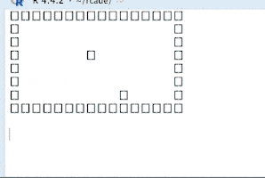

Working great!

## 9. Polish

Time for a bunch of cleanup and QoL.

### 9.1 U-Turn Prevention

Currently, there’s nothing stopping you from going back in the direction you just came from, which would make you instantly collide and lose. We can add a check in `Snake$set_direction()` to prevent this:

**`Snake$set_direction`**

```r
Snake$set_direction = function(RAM){
  #name of the actions pressed on this tick, or NULL
  actions = names(RAM$actions)[which(RAM$actions == TRUE)]

  #set head direction
  if (length(actions)) {
    action = actions[[1]]

    if (action != c( #forbidden direction combos
                    neutral = '', #can do any direction from neutral
                    left = 'right',
                    right = 'left',
                    up = 'down',
                    down = 'up'
                )[RAM$objects$head$direction]
        ){
            RAM$objects$head$direction = action
        }
  }

  return(RAM)
}
```

I’ve also gotten rid of the action echo, since we’re confident it works at this point.

### 9.2 Counting Segments and Survival

It would be neat to display some stats about the game when it ends, like how big the snake is and how long you survived for. We can record the snake length by incrementing a counter, `RAM$segments`, in `Snake$add_segment()`, and decrementing it in `Snake$remove_segment`.

**`Snake$spawn_segment`**

```r
Snake$spawn_segment = function(RAM){
    RAM$segments = RAM$segments + 1 #increment segments

    #spawn new tail segment
    RAM = ram.new_object(RAM, list(
        x = RAM$objects$head$x,
        y = RAM$objects$head$y,

        #used to find which objects are tail objects
        is_segment = TRUE,

        #tick on which this segment spawned
        time_created = RAM$ticks,

        spritename = 'pixel'
    ))

    return(RAM)
}

Snake$remove_tail = function(RAM){
    RAM$segments = RAM$segments - 1 #decrement segments

    oldest_time = Inf
    oldest_index = NULL
    for (i in 1:length(RAM$objects)){
        obj = RAM$objects[[i]]

        if (!is.null(obj$is_segment)){ #obj has $is_segment property
            if (obj$time_created < oldest_time){ #object is oldest so far
                oldest_time = obj$time_created
                oldest_index = i
            }
        }
    }
    #remove oldest segment
    RAM$objects = RAM$objects[-oldest_index]

    return(RAM)
}
```

Similarly, we can track the number of ticks survived by incrementing a counter every tick once the player starts moving, in `Snake$custom()`.

```r
RAM$ticks_survived = RAM$ticks_survived + 1
```

We just have to initialize both counters in `Snake$startup()` like so:

```r
RAM$segments = 0
RAM$ticks_survived = 0
```

And we can add these variables to the Game Over message:

**`Snake$end_game`**

```r
Snake$end_game = function(RAM){
        cat('Game over! Size: ',
            RAM$segments,
            '. Time survived: ',
            RAM$ticks_survived,
            '.',
        sep='')

        ram.end() #stops the game
}
```

We also want to make a check for when the player has completely filled the space with the snake, to prevent that while loop from earlier from hanging. We can do this by adding a check at the beginning of `Snake$eat_apple()`:

**`Snake$eat_apple`**

```r
Snake$eat_apple = function(RAM){
    # check for game win
    if (RAM$segments > (RAM$ROM$screen.width - 2) * (RAM$ROM$screen.height - 2)){
        cat('You win!')
        RAM = RAM$ROM$end_game(RAM)
    }

    valid = FALSE #is the apple in a valid location?

    #loop until the apple is in a valid (unoccupied) location
    while (!valid){
        valid = TRUE

        #new random location
        RAM$objects$apple$x = sample(2:(RAM$ROM$screen.width - 1),1)
        RAM$objects$apple$y = sample(2:(RAM$ROM$screen.height - 1),1)

        #overlapping anything? check all the segments again
        for (i in 1:length(RAM$objects)){
            obj = RAM$objects[[i]]
            if (!is.null(obj$is_tail)){
                if (RAM$ROM$overlap(RAM$objects$apple,obj)) {
                    #overlaps something, break out and try again with a new location
                    valid = FALSE
                    break
                }
            }
        }
    }

    return(RAM)
}
```

This will end the game before the while loop has a chance to start.

### 9.3 Starting Segments

It’s nice to start with a few segments. We can do this by suppressing `Snake$remove_tail()` in `Snake$custom()` until the desired amount of segments is reached, which we’ll define with `RAM$starting_segments`.

```r
if (RAM$segments > RAM$starting_segments) RAM = RAM$ROM$remove_tail(RAM)
```

And `RAM$starting_segments` also has to be initialized in `Snake$startup()`. I’ve set it to a default of 10 to skip the boring part of the game.

### 9.4 Difficulty Choice

Snake is much harder at different speeds and bounding regions— let’s give the player the choice to define their own.  
We can do this by putting `readline()` in `Snake$startup`, which will prompt the player during `ram.init()`.

**`Snake$set_difficulty`**

```r
Snake$set_difficulty = function(RAM){
    use_defaults = readline('Use default game settings? y/n ')

    if (use_defaults == 'n'){

        desired_framerate = as.integer(readline(paste(
            "How FAST should the game be? ",
            "Input an integer or leave blank for default.",
            "2: Easy",
            "5: Default",
            "10: Hard",
            ''
            ,sep='\n')))

        desired_width = as.integer(readline(paste(
            "How WIDE should the game area be? ",
            "Input an integer or leave blank for default.",
            "Default: 32",
            ''
            ,sep='\n')))

        desired_height = as.integer(readline(paste(
            "How TALL should the game area be? ",
            "Input an integer or leave blank for default.",
            "Default: 16",
            ''
            ,sep='\n')))

        desired_segments = as.integer(readline(paste(
            "How LONG should the snake start at? ",
            "Input an integer or leave blank for default.",
            "Default: 0",
            ''
            ,sep='\n')))

        #default if blank or nonnumber
        if (!is.na(desired_framerate)) RAM$ROM$framerate = desired_framerate
        if (!is.na(desired_width))  RAM$ROM$screen.width = desired_width
        if (!is.na(desired_height)) RAM$ROM$screen.height = desired_height
        if (!is.na(desired_segments)) RAM$starting_segments = desired_segments

    }

    return(RAM)
}
```

I’m also changing the defaults of the final ROM to 32x16 @ 5fps. We had it smaller before for ease of testing.  
For the framerate: 5fps is a nice, mildly challenging pace, 2 gives plenty of time to think, and 10 is rather intense and breakneck, especially as the snake gets long.

## 10. Game Demo

Here’s the (almost) final code for the `Snake` ROM, and a GIF of a complete game session.

**Code so far:**

```r
Snake = rom.init(32,16,framerate=5,sprites=list(pixel=matrix(1)))

#helper functions from before
Snake$set_direction = function...
Snake$move_head = function...
Snake$make_border = function...
Snake$spawn_segment = function...
Snake$remove_tail = function...
Snake$eat_apple = function...
Snake$check_game_end = function...
Snake$end_game = function...
Snake$set_difficulty = function...

Snake$startup = function(RAM){
    RAM$starting_segments = 10

    #set difficulty
    RAM = RAM$ROM$set_difficulty(RAM)

    #make border
    RAM = RAM$ROM$make_border(RAM)

    #make head
    RAM$objects$head = list(
        x = floor(RAM$ROM$screen.width / 2),
        y = floor(RAM$ROM$screen.height / 2),
        spritename = 'pixel',
        direction = 'neutral'
    )

    #make apple
    RAM$objects$apple = list(
        x = sample(2:(RAM$ROM$screen.width - 1),1), #random location
        y = sample(2:(RAM$ROM$screen.height - 1),1),

        spritename = 'pixel'
    )

  RAM$segments = 0
  RAM$ticks_survived = 0

  RAM$data = list(x = numeric(0), y = numeric(0), direction = character(0), segments = numeric(0))

  return(RAM)
}

Snake$custom = function(RAM){
  #only do segment stuff once the snake starts moving
  if (RAM$objects$head$direction != 'neutral'){
    RAM = RAM$ROM$spawn_segment(RAM)

    RAM$ticks_survived = RAM$ticks_survived + 1

    #eat apple or remove tail
    if (RAM$ROM$overlap(RAM$objects$head,RAM$objects$apple)){
            RAM = RAM$ROM$eat_apple(RAM) #eat apple
        }
    else if (RAM$segments > RAM$starting_segments) {
            RAM = RAM$ROM$remove_tail(RAM)
        }
            #once the starting number of segments has been reached, start removing the tail
  }

    #move snake
  RAM = RAM$ROM$set_direction(RAM)
  RAM = RAM$ROM$move_head(RAM)

  #check for game end
  RAM = RAM$ROM$check_game_end(RAM)

  return(RAM)
}


quickload(Snake)
```

[figure not shown]

You can see me:

1. create the RAM with `ram.init()`
2. start running the game with `ram.run()`
3. pull up the input session
4. start recording and inputting inputs with `inputs.listen()`

## 11. Advanced Data Collection

In the spirit of R, why not make some pretty graphs? It should be trivial to record some basic data on each tick and process it when the game is over.

We’ll initialize the variables in `Snake$startup()`:

```r
RAM$data = list(x = numeric(0), y = numeric(0), direction = character(0), segments = numeric(0))
```

And then stick a function to record them in `Snake$custom()` once the snake starts moving.

**`Snake$record_data`**

```r
Snake$record_data = function(RAM){
    #position
    RAM$data$x = c(RAM$data$x, RAM$objects$head$x)
    RAM$data$y = c(RAM$data$y, RAM$objects$head$y)
    #direction
    RAM$data$direction = c(RAM$data$direction, RAM$objects$head$direction)
    #segments
    RAM$data$segments = c(RAM$data$segments, RAM$segments)

    return(RAM)
}
```

And now let’s make some graphs. We’ll call this inside `Snake$end_game()`: here’s a demo with a round I played.

**`Snake$view_data`**

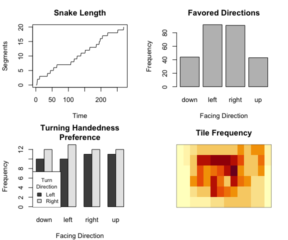

```r
Snake$view_data = function(RAM){
    if (readline("View graphs? y/n ") != 'y') return()

    op = par(mfrow = c(1,1), mar = c(5, 4, 4, 2) + 0.1)
    par(mfrow=c(2,2), mar = c(4,4,3,2) + 0.1)

    data = RAM$data

    #plot 1: segments over time
    plot(data$segments,type='l',xlab='Time',ylab='Segments',main='Snake Length')

    #plot 2: direction frequency
    barplot(table(data$direction),xlab='Facing Direction',ylab='Frequency',main='Favored Directions')

    #plot 3: handedness preference
    handedness = list(
        right = c(up='Left',down='Right'),
        left = c(down='Left',up='Right'),
        up = c(left='Left',right='Right'),
        down = c(right='Left',left='Right')
    )
    hand_direction = c() #handedness direction of each turn (or NA if no turn)
    for (d in 1:(length(data$direction) - 1)) hand_direction = c(hand_direction,handedness[[data$direction[d]]][data$direction[d + 1]])
    hand_table = data.frame("direction" = data$direction[1:(length(data$direction)-1)], "turn" = hand_direction)
    barplot(t(table(hand_table)), beside=TRUE, main = 'Turning Handedness\nPreference', xlab = 'Facing Direction', ylab = 'Frequency')
    legend('bottomleft', title= '\nTurn\nDirection', legend=c('Left','Right'), fill=gray.colors(2))

    #plot 4: tile frequency
    tile_heatmap = matrix(0,RAM$ROM$screen.height,RAM$ROM$screen.width)
    #using x and y position for each tick, get position frequencies
    for (tick in 1:length(data$x)){
            tile_heatmap[data$y[tick],data$x[tick]] = tile_heatmap[data$y[tick],data$x[tick]] + 1
    }
    tile_heatmap = tile_heatmap[2:(nrow(tile_heatmap)-1), 2:(ncol(tile_heatmap)-1)] #clip out the border
    tile_heatmap = tile_heatmap[nrow(tile_heatmap):1,] #flip upside-down to match the way the game is drawn
    image(1:ncol(tile_heatmap), 1:nrow(tile_heatmap), t(tile_heatmap),xlab='',ylab='',xaxt='n', yaxt='n', main= 'Tile Frequency')

    par(op) #restore original settings
}
```

I only got to 20 (out of 84 max) segments, so these graphs represent data for the early stages of the game.

It could also be cool to look at apple spawns (and how that correlates with where the snake moved), but I think this is enough for now.

[^1]: See `?inputs.process` for more info on how keybinds are set and interpreted.
[^2]: It’s a *game systems* bug— a mistake that doesn’t immediately crash the game (unlike a syntax error), but instead changes the gamestate in a valid but unintended way, which leads to crashes later on. This is how the majority of game bugs go in any language, and squashing them is a skill that can take a while to build. I’d say the two most important parts are:
    1. Having intuition for how these sorts of bugs manifest and work.
    2. Knowing where to debug (print info) in the code to narrow down the possible causes.